# Early Secondary Assessment & GPA

# V. Appendix

### A. Diagnostics for Predictors

A stripchart (jittered), boxplot, and histogram is used to identify the distribution and shape of each continuous predictor variable and the variable of interest (GPA).

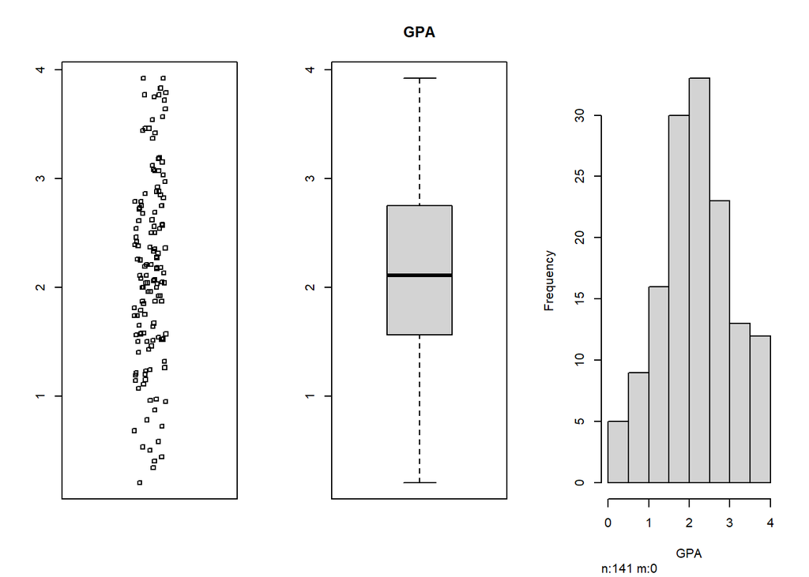

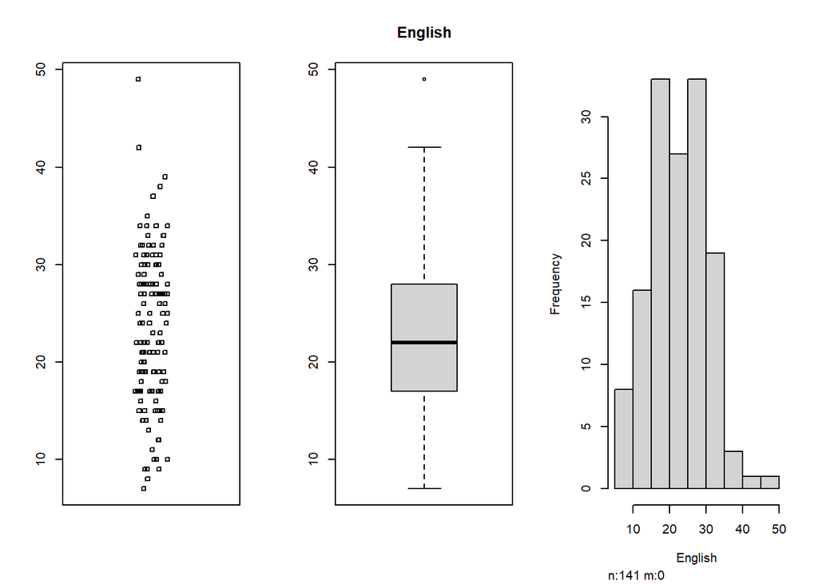

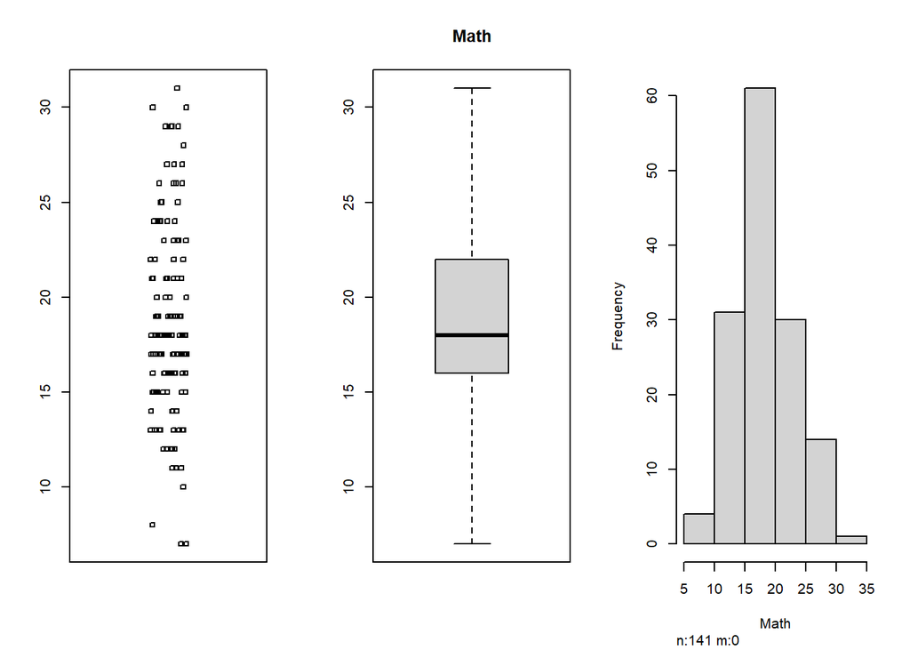

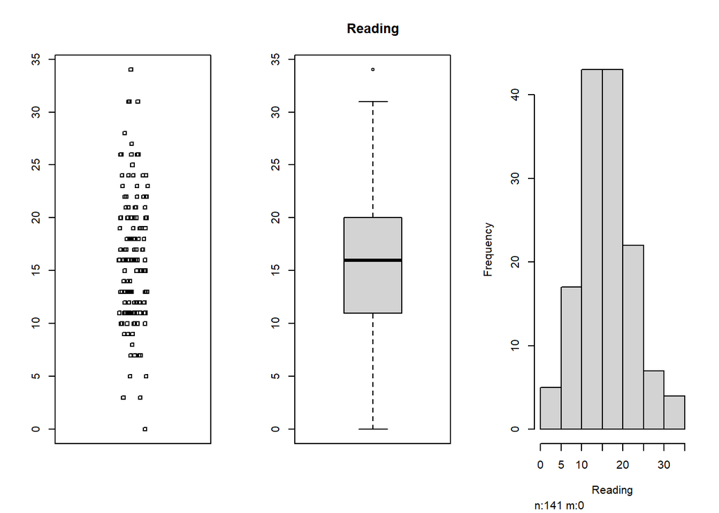

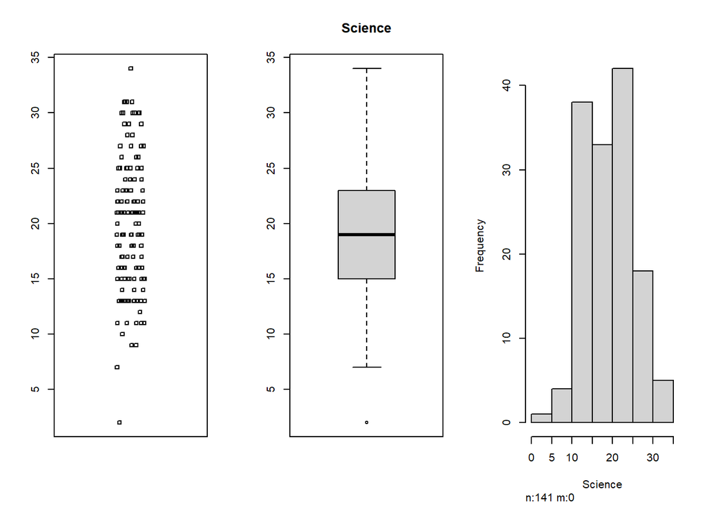

Tables of each of the variables based upon whether or not the students were flagged for services appear to indicate that there are no significant differences.

Table of variate means based on whether or not student was flagged for services.

|  | GPA | English | Math | Reading | Science |
| --- | --- | --- | --- | --- | --- |
| No | 2.169437 | 23.91549 | 18.61972 | 16.26761 | 19.61972 |
| Yes | 2.153000 | 22.10000 | 18.61429 | 15.97143 | 19.31429 |

Table of variate standard deviation based on whether or not student was flagged for services.

|  | GPA | English | Math | Reading | Science |
| --- | --- | --- | --- | --- | --- |
| No | 0.8167145 | 7.202671 | 4.586833 | 6.641768 | 6.417312 |
| Yes | 0.9353545 | 7.954854 | 5.322343 | 5.697626 | 5.668481 |

### B. Screening of Predictors

1. **The Added Variable** plots are shown. The plots indicate the importance of a covariate in a model if all other covariates are included in the model. A covariate that adds value will have a linear(or curvilinear) pattern of the residuals. The plots also indicate if any transformations are necessary for the covariate. Since the plots all show an equal, random spread of residuals about the line (flag is still random because 0 and 1 are the only possible values), it does not appear that any transformations of covariates is necessary.  
   Bases upon the plots, English and Science scores appear to be the most important values when all other covariates are included in the model. It also appears that whether a student is flagged for services(Flag) does not appear to add any value to a model that includes all other covariates.

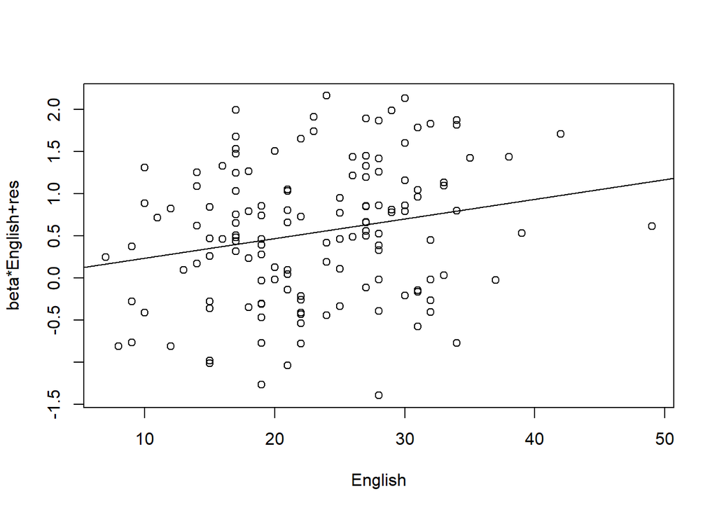

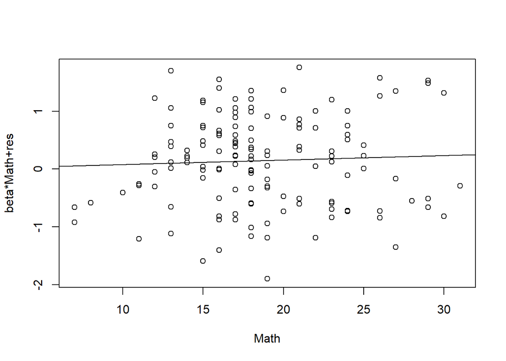

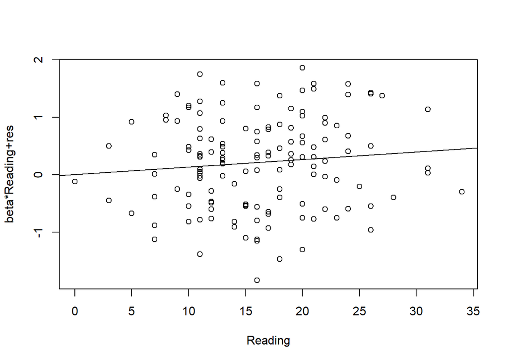

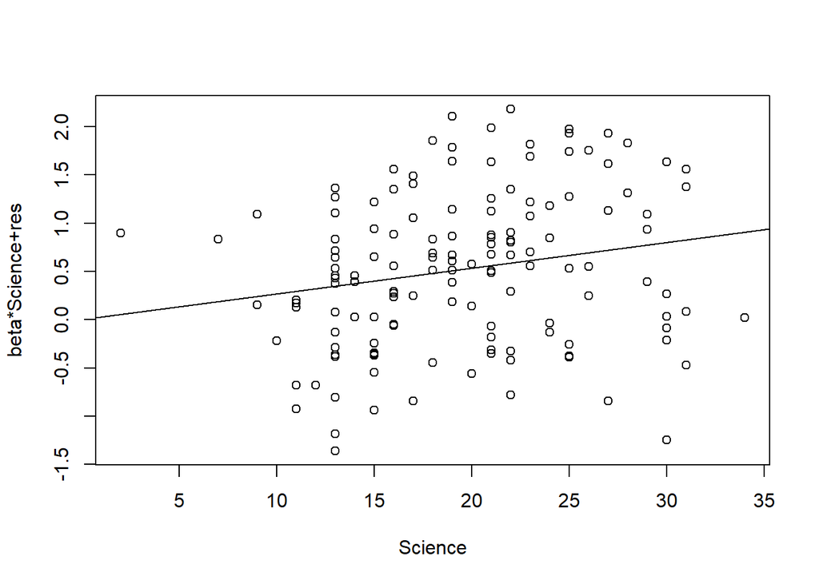

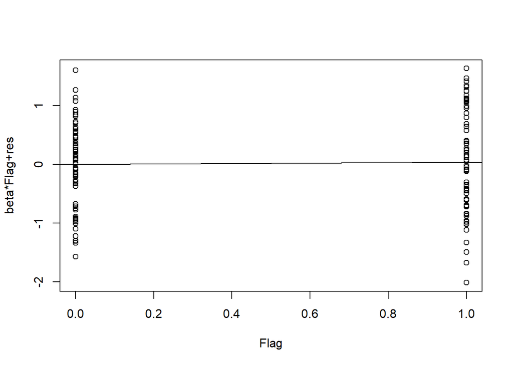

2. **Multicollinearity** can create instability in estimation. Being that our main purpose is for prediction, the issues observed with multicollinearity can largely be ignored. It observed that most covariate have a moderate to high correlation. Science/Reading($r=$ 0.641 ) and Science/English ($r=$ 0.577 ) have the highest correlation.

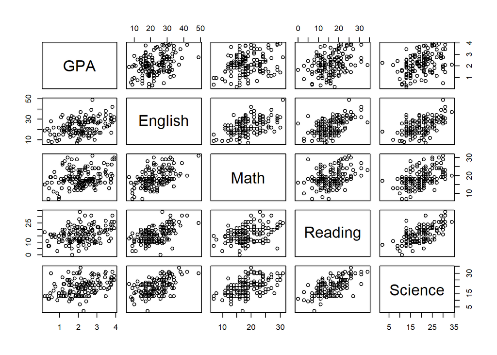

Figure 1: A Scatterplot of variates.

Figure 2: Pearson’s Correlation Coefficients Matrix.

|  | GPA | English | Math | Reading | Science |
| --- | --- | --- | --- | --- | --- |
| GPA | 1.0000000 | 0.3818151 | 0.2716689 | 0.3433478 | 0.3833535 |
| English | 0.3818151 | 1.0000000 | 0.4880620 | 0.5625412 | 0.5774962 |
| Math | 0.2716689 | 0.4880620 | 1.0000000 | 0.3987678 | 0.4895330 |
| Reading | 0.3433478 | 0.5625412 | 0.3987678 | 1.0000000 | 0.6409472 |
| Science | 0.3833535 | 0.5774962 | 0.4895330 | 0.6409472 | 1.0000000 |

3. **Automatic variable selection methods** can be a useful starting point in eliminating redundant variables. The function *regsubsets()* using the exhaustive method was used to identify the three best subsets parameter values.

```
## Subset selection object
## Call: regsubsets.formula(GPA ~ English + Math + Reading + Science +
##     Flag, data = m.Grades)
## 5 Variables  (and intercept)
##         Forced in Forced out
## English     FALSE      FALSE
## Math        FALSE      FALSE
## Reading     FALSE      FALSE
## Science     FALSE      FALSE
## Flag        FALSE      FALSE
## 1 subsets of each size up to 5
## Selection Algorithm: exhaustive
##          English Math Reading Science Flag
## 1  ( 1 ) " "     " "  " "     "*"     " "
## 2  ( 1 ) "*"     " "  " "     "*"     " "
## 3  ( 1 ) "*"     " "  "*"     "*"     " "
## 4  ( 1 ) "*"     "*"  "*"     "*"     " "
## 5  ( 1 ) "*"     "*"  "*"     "*"     "*"
```

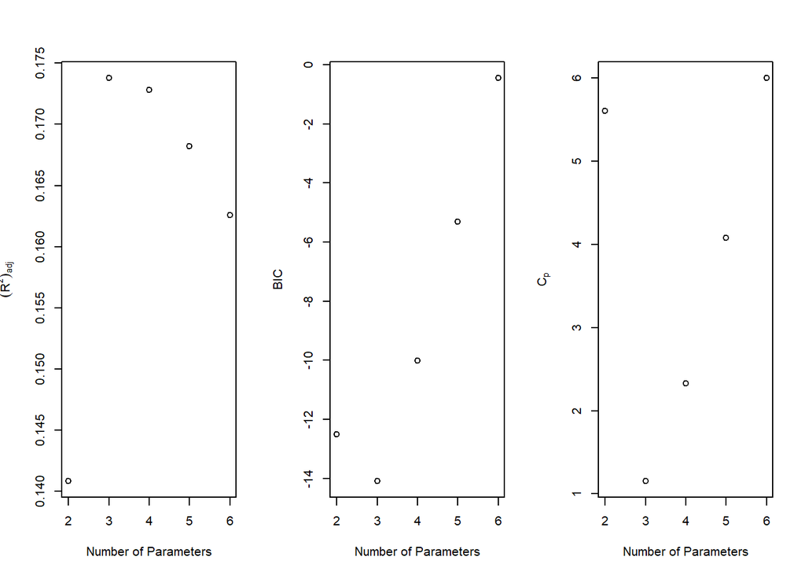

Table of decision criteria based upon the number of parameters, p, in the model.

|  | 2 | 3 | 4 | 5 | 6 |
| --- | --- | --- | --- | --- | --- |
| Adjusted coefficient of Determination | 0.141 | 0.174 | 0.173 | 0.168 | 0.163 |
| BIC | -12.514 | -14.097 | -10.006 | -5.315 | -0.448 |
| Mallows Cp | 5.607 | 1.151 | 2.326 | 4.078 | 6.000 |
| p-Mallows Cp | -3.607 | 1.849 | 1.674 | 0.922 | 0.000 |

$Y_i =$ the **GPA** of the $i^{th}$ student,

$X_{i1}=$ the **English** score for the $i^{th}$ student,

$X_{i2}=$ the **Math** score for the $i^{th}$ student,

$X_{i3}=$ the **Reading** score for the $i^{th}$ student,

$X_{i4}=$ the **Science** score for the $i^{th}$ student,

$X_{i5}=$ whether or not the $i_{th}$ student has ever been flagged for services, with $X_5 = 1$ for “yes” and $X_5 = 0$ for “no”.

The 3 parameter model, $Y_i = \beta_0 + \beta_1X_{i1} + \beta_4X_{i4} + \varepsilon_i$ appears to have the comparable bias according to $C_p$ criterion. It is also the model that presents the significantly smallest BIC and is the largest $R^2_{adj}$. Thus, this is the chosen model to be used for validation.

4. Formal testing for **multicollinearity** can now be done using **variance inflation factors (VIF)**. Although it is not necessary for prediction, it is useful information. VIFs measure how much the variances of the estimated regression coefficients are inflated as compared to when the predictor variables are not linearly related. A maximum VIF in excess of 10 is a good rule of thumb for multicollinearity problems. Based on the maximum VIF, 1.5003792, there do not appear to be any issues that need would need remediation.

|  | VIF |
| --- | --- |
| English | 1.500379 |
| Science | 1.500379 |

### C. Model Validation

1. **A validation data set** is used to compare the model chosen from the training data set. If the model is valid, we should get similar results in the validation data set as we did in the training data set. The chosen model was fit using the validation set, then the estimates of the regression coefficients, their standard deviations, each models error mean squares, and each models $R^2_{adj}$ are compared.  
   In general, the estimates of the model fitted to the validation data set was similar to that of the model building data set. Difference in the coefficients should be expected based upon the multicollinearity of English and Science. This should not affect the predictive power of the final model.

Table of coefficients and their standard error for the model building and validation set.

|  | (Intercept) | English | Science |
| --- | --- | --- | --- |
| Training Set Coefficients | 0.8358886 | 0.0276503 | 0.0353932 |
| Validation Set Coefficients | 1.1442256 | 0.0103134 | 0.0378519 |
| Training Set Standard Error | 0.2460416 | 0.0108094 | 0.0136301 |
| Validation Set Standard Error | 0.2522927 | 0.0121161 | 0.0125264 |

Table of mean square error and adjusted R.Squared for the model building and validation set.

|  | MSE | Adjusted R.Squared |
| --- | --- | --- |
| Training Set | 0.6318769 | 0.1737731 |
| Validation Set | 0.6916467 | 0.1082880 |

2. The **mean square prediction error (MSRP)** calculates the MSE of the model built from the training data set when it is fit to the validation data set. The mean square prediction error (MSRP) is then compared to the $MSE_p$ (MSE of the model data set). The MSPR is reasonably close to the MSE of the model-building data set. This suggest that there is not substantial bias in the model and thus is valid.

| MSPR | MSE |
| --- | --- |
| 0.6900275 | 0.6318769 |

3. Now that the model has been validated, the model is fit to the **full data set**. The process of comparing the estimates of the regression coefficients, their standard deviations, each models error mean squares, and each models $R^2_{adj}$ was repeated to observe the fit. It is expected that the standard error of the model coefficients will be smaller in the full model, due to the difference in size of the data set.

Table of coefficients and their standard error for the model building and validation set.

|  | (Intercept) | English | Science |
| --- | --- | --- | --- |
| Training Set Coefficients | 0.8358886 | 0.0276503 | 0.0353932 |
| Full Data Set Coefficients | 0.9880916 | 0.0203321 | 0.0355638 |
| Training Set Standard Error | 0.2460416 | 0.0108094 | 0.0136301 |
| Full Data Set Standard Error | 0.1754792 | 0.0079037 | 0.0089880 |

Table of mean square error and adjusted R.Squared for the model building and full data set.

|  | MSE | Adjusted R.Squared |
| --- | --- | --- |
| Training Set | 0.6318769 | 0.1737731 |
| Full Set | 0.6583435 | 0.1421892 |

**If a check of residual analysis determines no issues, this will be the final model.**

### D. Residual Diagnostics

1. The **plots of the residuals** against the fitted values and each of the predictor variables indicate that no modifications to the model should be made. The residuals have no systematic departure from 0 in any of the plots. There also appears to be constant variance across the fitted values.

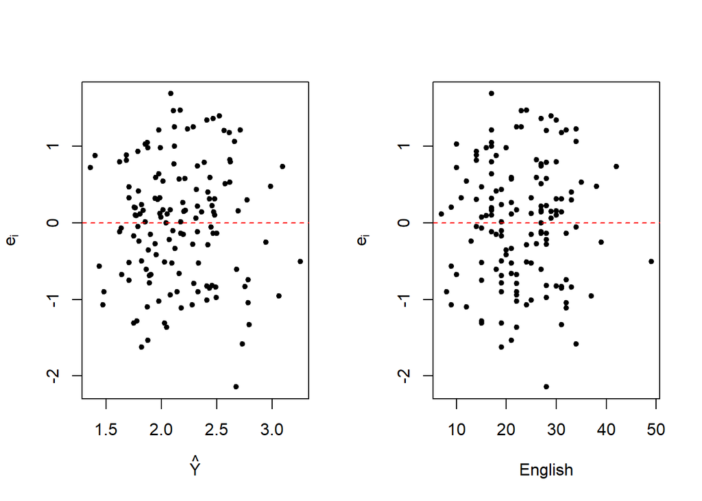

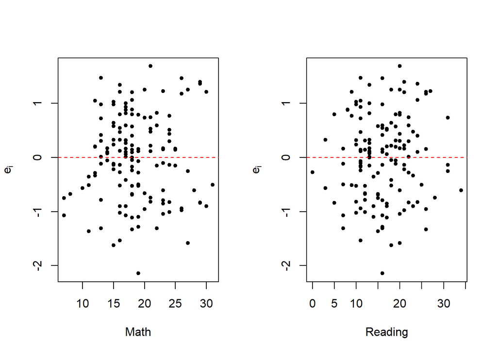

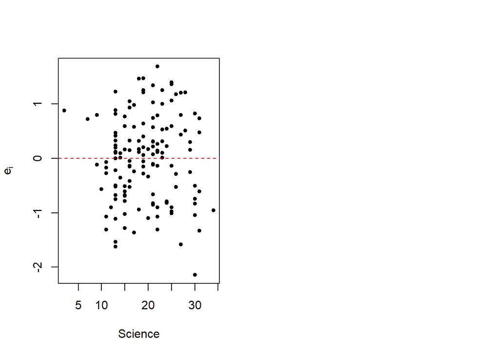

2. An exploration of potential **high leverage** cases, 109 and 35, was undertaken to determine their **influence**. After obtaining the DFFITS, DFBETAS, and Cook’s distance for each of the cases, they were determined to have no significant influence. No cases had a value greater than 1 (general rule of thumb for both DFFITS and DFBETAS) in either the DFFITS and DFBETAS.

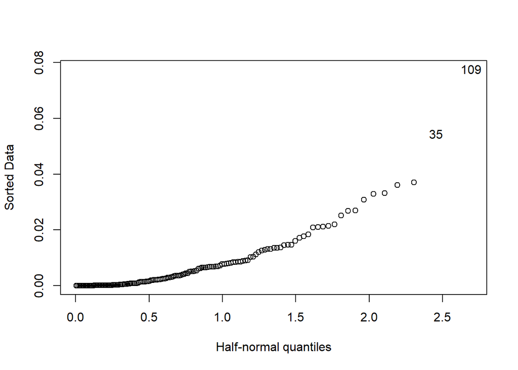

|  | Cook’s Distance | DFFITS | DFBETAS |
| --- | --- | --- | --- |
| 35 | 0.0169521 | -0.2254776 | 0.0765824 |
| 109 | 0.0075660 | -0.1505712 | 0.0397617 |

3. The assumption of **Constancy** in error terms (residuals) is observed in the residual plots above. A Breusch-Pagan test for constant variance confined this assumption ($p=$ 0.24 ).
4. Error terms appear to be **independent** based on the sequence plot.

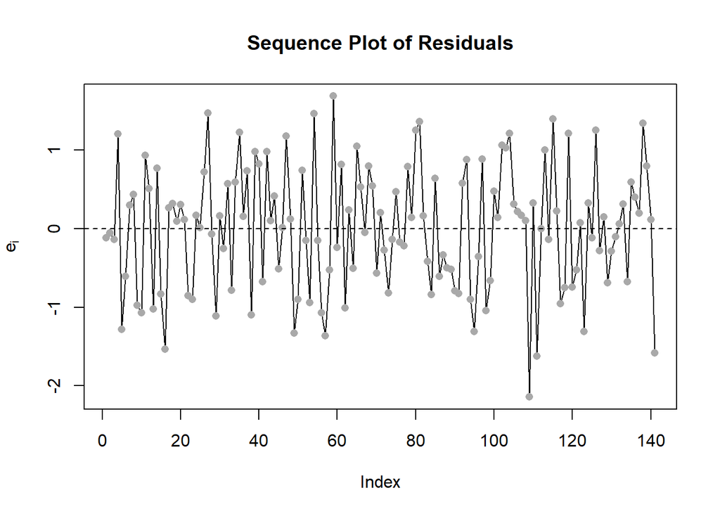

5. **Normallity** of the residuals is assessed in the normal Q-Q Plot below. There appears to be no significant departure from normality. The coefficient of correlation between theoretical and sample quartiles 0.9946 both indicate that the assumption of normality is reasonable.

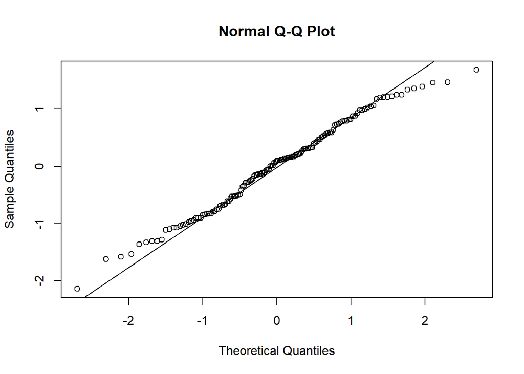

All of the statistical analyses in this document will be performed using R version 4.1.2 (2021-11-01). R packages used will be maintained using the [packrat](http://rstudio.github.io/packrat/) dependency management system.